# Part I - February 2019 FordGoBike Trip Data

## Introduction

Ford GoBike is a bike sharing service syatem. The dataset includes information about bike trips covering San Francisco Bay area for the month of February. The bike sharing service is for Subscribers, who pay subscription fee, or Customers, who rent bikes on-the-go. The dataset can be downloaded here

## Preliminary Wrangling

I would commence by importing the requisite packages, loading and having an overview of the dataset to better understand it's features.

```python
# import all packages and set plots to be embedded inline
import numpy as np
import pandas as pd
import matplotlib.pyplot as plt
import seaborn as sb

%matplotlib inline
```

```python
#load dataset
df = pd.read_csv('201902-fordgobike-tripdata.csv')
df.head()
```

|  | duration_sec | start_time | end_time | start_station_id | start_station_name | start_station_latitude | start_station_longitude | end_station_id | end_station_name | end_station_latitude | end_station_longitude | bike_id | user_type | member_birth_year | member_gender | bike_share_for_all_trip |
| --- | --- | --- | --- | --- | --- | --- | --- | --- | --- | --- | --- | --- | --- | --- | --- | --- |
| 0 | 52185 | 2019-02-28 17:32:10.1450 | 2019-03-01 08:01:55.9750 | 21.0 | Montgomery St BART Station (Market St at 2nd St) | 37.789625 | -122.400811 | 13.0 | Commercial St at Montgomery St | 37.794231 | -122.402923 | 4902 | Customer | 1984.0 | Male | No |
| 1 | 42521 | 2019-02-28 18:53:21.7890 | 2019-03-01 06:42:03.0560 | 23.0 | The Embarcadero at Steuart St | 37.791464 | -122.391034 | 81.0 | Berry St at 4th St | 37.775880 | -122.393170 | 2535 | Customer | NaN | NaN | No |
| 2 | 61854 | 2019-02-28 12:13:13.2180 | 2019-03-01 05:24:08.1460 | 86.0 | Market St at Dolores St | 37.769305 | -122.426826 | 3.0 | Powell St BART Station (Market St at 4th St) | 37.786375 | -122.404904 | 5905 | Customer | 1972.0 | Male | No |
| 3 | 36490 | 2019-02-28 17:54:26.0100 | 2019-03-01 04:02:36.8420 | 375.0 | Grove St at Masonic Ave | 37.774836 | -122.446546 | 70.0 | Central Ave at Fell St | 37.773311 | -122.444293 | 6638 | Subscriber | 1989.0 | Other | No |
| 4 | 1585 | 2019-02-28 23:54:18.5490 | 2019-03-01 00:20:44.0740 | 7.0 | Frank H Ogawa Plaza | 37.804562 | -122.271738 | 222.0 | 10th Ave at E 15th St | 37.792714 | -122.248780 | 4898 | Subscriber | 1974.0 | Male | Yes |

```python
#overview of dataset
print('Shape of dataset:',df.shape)
print('\nNumber of unique values for each feature:\n',df.nunique(),'\n')
print(df.info())
df.head(5)
```

```
Shape of dataset: (183412, 16)

Number of unique values for each feature:
 duration_sec                 4752
start_time                 183401
end_time                   183397
start_station_id              329
start_station_name            329
start_station_latitude        334
start_station_longitude       335
end_station_id                329
end_station_name              329
end_station_latitude          335
end_station_longitude         335
bike_id                      4646
user_type                       2
member_birth_year              75
member_gender                   3
bike_share_for_all_trip         2
dtype: int64

<class 'pandas.core.frame.DataFrame'>
RangeIndex: 183412 entries, 0 to 183411
Data columns (total 16 columns):
 #   Column                   Non-Null Count   Dtype
---  ------                   --------------   -----
 0   duration_sec             183412 non-null  int64
 1   start_time               183412 non-null  object
 2   end_time                 183412 non-null  object
 3   start_station_id         183215 non-null  float64
 4   start_station_name       183215 non-null  object
 5   start_station_latitude   183412 non-null  float64
 6   start_station_longitude  183412 non-null  float64
 7   end_station_id           183215 non-null  float64
 8   end_station_name         183215 non-null  object
 9   end_station_latitude     183412 non-null  float64
 10  end_station_longitude    183412 non-null  float64
 11  bike_id                  183412 non-null  int64
 12  user_type                183412 non-null  object
 13  member_birth_year        175147 non-null  float64
 14  member_gender            175147 non-null  object
 15  bike_share_for_all_trip  183412 non-null  object
dtypes: float64(7), int64(2), object(7)
memory usage: 22.4+ MB
None
```

|  | duration_sec | start_time | end_time | start_station_id | start_station_name | start_station_latitude | start_station_longitude | end_station_id | end_station_name | end_station_latitude | end_station_longitude | bike_id | user_type | member_birth_year | member_gender | bike_share_for_all_trip |
| --- | --- | --- | --- | --- | --- | --- | --- | --- | --- | --- | --- | --- | --- | --- | --- | --- |
| 0 | 52185 | 2019-02-28 17:32:10.1450 | 2019-03-01 08:01:55.9750 | 21.0 | Montgomery St BART Station (Market St at 2nd St) | 37.789625 | -122.400811 | 13.0 | Commercial St at Montgomery St | 37.794231 | -122.402923 | 4902 | Customer | 1984.0 | Male | No |
| 1 | 42521 | 2019-02-28 18:53:21.7890 | 2019-03-01 06:42:03.0560 | 23.0 | The Embarcadero at Steuart St | 37.791464 | -122.391034 | 81.0 | Berry St at 4th St | 37.775880 | -122.393170 | 2535 | Customer | NaN | NaN | No |
| 2 | 61854 | 2019-02-28 12:13:13.2180 | 2019-03-01 05:24:08.1460 | 86.0 | Market St at Dolores St | 37.769305 | -122.426826 | 3.0 | Powell St BART Station (Market St at 4th St) | 37.786375 | -122.404904 | 5905 | Customer | 1972.0 | Male | No |
| 3 | 36490 | 2019-02-28 17:54:26.0100 | 2019-03-01 04:02:36.8420 | 375.0 | Grove St at Masonic Ave | 37.774836 | -122.446546 | 70.0 | Central Ave at Fell St | 37.773311 | -122.444293 | 6638 | Subscriber | 1989.0 | Other | No |
| 4 | 1585 | 2019-02-28 23:54:18.5490 | 2019-03-01 00:20:44.0740 | 7.0 | Frank H Ogawa Plaza | 37.804562 | -122.271738 | 222.0 | 10th Ave at E 15th St | 37.792714 | -122.248780 | 4898 | Subscriber | 1974.0 | Male | Yes |

### What is the structure of your dataset?

The dataset is made of 183,412 bike trips with 16 features namely:

1. Duration (in seconds)
2. Start time
3. End time
4. Start station id
5. Start station name
6. Start station latitude
7. Start station longitude
8. End station id
9. End station name
10. End station latitude
11. End station longitude
12. Bike id
13. User type (Customer or Subscriber)
14. Member birth year
15. Member gender
16. Bike share for all trip (Yes or No)

### What is/are the main feature(s) of interest in your dataset?

My interest is to determine when most bikes are rented taking into consideration the age and user type of riders.

### What features in the dataset do you think will help support your investigation into your feature(s) of interest?

Duration, start time, user type and member birth year are features that would aid this analysis.

From the overview of our dataset, there is need for a little data wrangling to prepare the data for analysis. This means the following:

```
- our features of interest would be changed to it's appropriate datatype
- date and time would be separated in start_time and end_time columns
```

```python
# Convert start_time and end_time to datetime datatypes
df.start_time = pd.to_datetime(df.start_time)
df.end_time = pd.to_datetime(df.end_time)
df.dtypes
```

```
duration_sec                        int64
start_time                 datetime64[ns]
end_time                   datetime64[ns]
start_station_id                  float64
start_station_name                 object
start_station_latitude            float64
start_station_longitude           float64
end_station_id                    float64
end_station_name                   object
end_station_latitude              float64
end_station_longitude             float64
bike_id                             int64
user_type                          object
member_birth_year                 float64
member_gender                      object
bike_share_for_all_trip            object
dtype: object
```

```python
# Using list comprehension, create date and time columns from start_time column
df['start_dates'] = [i.date() for i in df['start_time']]
df['start_times'] = [i.time() for i in df['start_time']]

# Create column for day of the week
df['day_of_week'] = [i.dayofweek for i in df['start_time']]

# Create column for hour of the day
df['time_of_day'] = [i.hour for i in df['start_time']]
```

```python
df.info()
```

```
<class 'pandas.core.frame.DataFrame'>
RangeIndex: 183412 entries, 0 to 183411
Data columns (total 20 columns):
 #   Column                   Non-Null Count   Dtype
---  ------                   --------------   -----
 0   duration_sec             183412 non-null  int64
 1   start_time               183412 non-null  datetime64[ns]
 2   end_time                 183412 non-null  datetime64[ns]
 3   start_station_id         183215 non-null  float64
 4   start_station_name       183215 non-null  object
 5   start_station_latitude   183412 non-null  float64
 6   start_station_longitude  183412 non-null  float64
 7   end_station_id           183215 non-null  float64
 8   end_station_name         183215 non-null  object
 9   end_station_latitude     183412 non-null  float64
 10  end_station_longitude    183412 non-null  float64
 11  bike_id                  183412 non-null  int64
 12  user_type                183412 non-null  object
 13  member_birth_year        175147 non-null  float64
 14  member_gender            175147 non-null  object
 15  bike_share_for_all_trip  183412 non-null  object
 16  start_dates              183412 non-null  object
 17  start_times              183412 non-null  object
 18  day_of_week              183412 non-null  int64
 19  time_of_day              183412 non-null  int64
dtypes: datetime64[ns](2), float64(7), int64(4), object(7)
memory usage: 28.0+ MB
```

```python
df.duplicated().sum()
```

```
0
```

## Univariate Exploration

In this section, I'll look at individual features, including user type, birth year and duration of trip, which are of essence in this analysis.

#### Birth year/Age feature

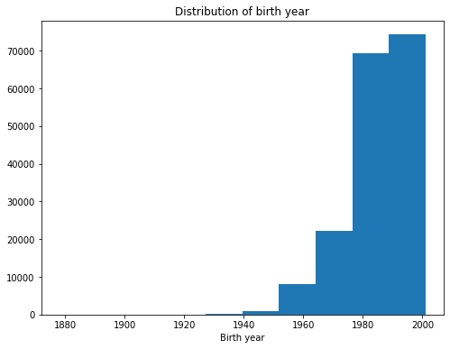

```python
# Histogram of distribution of riders by their birth year
plt.figure(figsize=[8, 6])
plt.hist(df.member_birth_year)
plt.xlabel('Birth year')
plt.title('Distribution of birth year');
```

```python
# Year of birth of the oldest rider in the dataset
print(df.member_birth_year.max())

# Year of birth of the youngest rider in the dataset
print(df.member_birth_year.min())
```

```
2001.0
1878.0
```

```python
# Number of birth years in the dataset
df.member_birth_year.nunique()
```

```
75
```

From the above histogram, most riders were born between 1980 and 2000. However, to get a clearer understanding of the distribution of riders according to their birth year, the bin size of the histogram would be reduced.

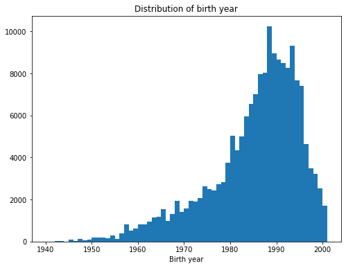

```python
# Binsize reduced to 1 and data plotted on a histogram
size = 1
bins = np.arange(1940, df['member_birth_year'].max()+size, size)

plt.figure(figsize=[8, 6])
plt.hist(df.member_birth_year, bins = bins)
plt.xlabel('Birth year')
plt.title('Distribution of birth year');
```

This gives a clearer understanding of the distribution of birth year in the dataset and shows that majority of riders were born between 1985 and 1995. Since the data was generated in 2019, 2019 would be used as the base year to calculate and group riders by age.

```python
# Calculate the age of riders
df['age'] = 2019 - df.member_birth_year

# Place riders in age groups
bins = [19, 20, 25, 30, 35, 40, 45, 50, 55, 60, 141]
labels = ['<20', '21-25', '26-30', '31-35', '36-40', '41-45', '46-50', '51-55', '56-60', '61+']
df['age_range'] = pd.cut(df.age, bins, labels=labels)
ages =df.age_range.value_counts(sort = False)
```

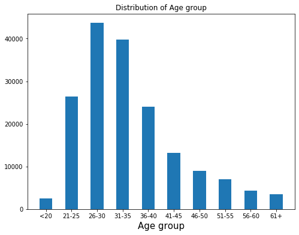

```python
# Plot bar chart by age group
plt.figure(figsize=[8, 6])
plt.bar(ages.index, ages, width=0.5)
plt.xlabel('Age group', size=15)
plt.title('Distribution of Age group');
```

Riders between 26 -30 years took most trips using Ford GoBike service, closely followed by those between 31 - 35 years.

Duration feature would be examined next.

#### Duration feature

```python
# Descriptive statistics of duration(in secs)
df.duration_sec.describe()
```

```
count    183412.000000
mean        726.078435
std        1794.389780
min          61.000000
25%         325.000000
50%         514.000000
75%         796.000000
max       85444.000000
Name: duration_sec, dtype: float64
```

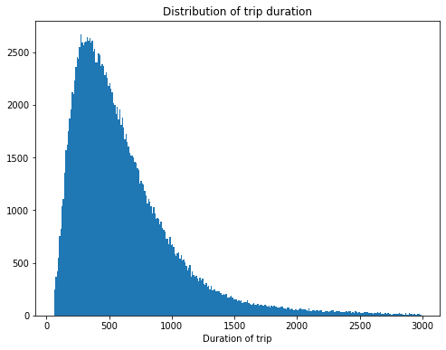

```python
size =10
bins = np.arange(61, 3000, size)

plt.figure(figsize=[8, 6])
plt.hist(df.duration_sec, bins = bins)
plt.xlabel('Duration of trip')
plt.title('Distribution of trip duration');
```

Distribution of trip duration is skewed to the right due to an outlier (maximum trip duration of 85,444 secs). However, majority of trips lasted less than 1000 seconds and the average trip duration is 726 seconds.

#### Time and Date feature

```python
# Date of first trip in the dataset
print(df.start_dates.min())

# Date of last trip in the dataset
print(df.start_dates.max())
```

```
2019-02-01
2019-02-28
```

The dataset contains entries for bike rides in the month of February 2019.

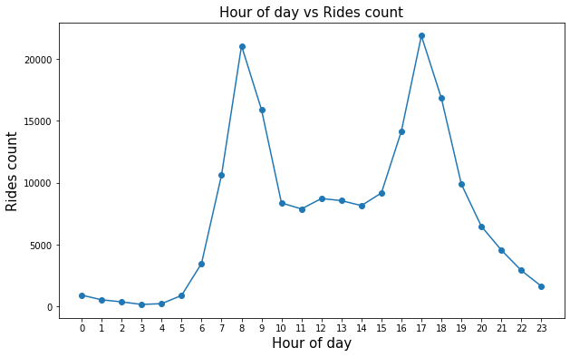

```python
# Line chart showing number of trips taken at various hours in the day
time =df.time_of_day.value_counts(sort=False)

plt.figure(figsize=[10, 6])
plt.plot(time.index, time, marker = 'o')
plt.xlabel('Hour of day', size=15)
plt.ylabel('Rides count', size=15)
plt.xticks(np.arange(24))
plt.title('Hour of day vs Rides count', size=15);
```

The Line chart shows that peak usage periods is around 8am (8:00) and 5pm (17:00) daily.

```python
# Create a column and categorize time into Night(00:00-4:00), Morning(5:00-11:00), Afternoon(12:00-17:00) and Evening(18:00-23:00).
bins = [0, 4, 12, 18, 23]
labels = ['Night', 'Morning', 'Afternoon', 'Evening']
df['time'] = pd.cut(df.time_of_day, bins, labels=labels, include_lowest = True)
time = df.time.value_counts(sort = False)
time
```

```
Night         2263
Morning      76926
Afternoon    78737
Evening      25486
Name: time, dtype: int64
```

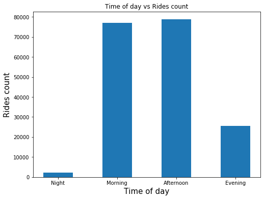

```python
# Plot bar chart of number of rides taken at night, in the morning , afternoon or evening
plt.figure(figsize=[8, 6])
plt.bar(time.index, time, width=0.5)
plt.xlabel('Time of day', size=15)
plt.ylabel('Rides count', size=15)
plt.title('Time of day vs Rides count');
```

```python
# Function for horizontal bar charts
def myChart(y, width):
    plt.figure(figsize=[10, 6])
    plt.barh(y=y, width=width, height=0.5)
    plt.ylabel('Day of week', size=15)
    sb.despine();
```

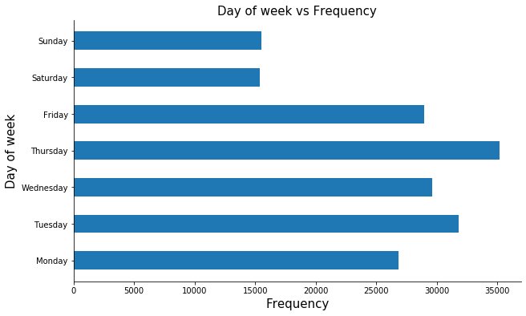

```python
# Number of trips taken by day of week
week = df.day_of_week.value_counts(sort=False)
order = ['Monday', 'Tuesday', 'Wednesday', 'Thursday', 'Friday', 'Saturday', 'Sunday']

# Bar chart for trips taken by day of week
myChart(order,week)
plt.xlabel('Frequency', size=15)
plt.title('Day of week vs Frequency', size=15);
```

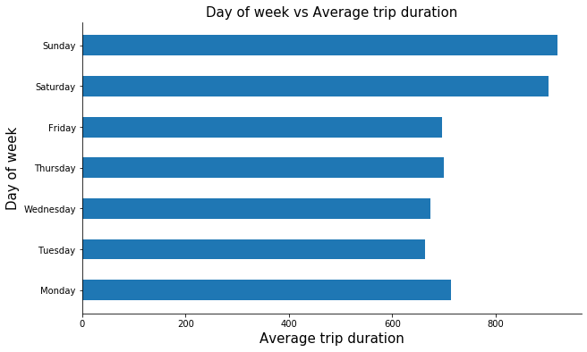

```python
# Average trip duration
y=df.groupby('day_of_week').duration_sec.mean()

# Chart for average trip duration
myChart(order,y)
plt.xlabel('Average trip duration', size=15)
plt.title('Day of week vs Average trip duration', size=15);
```

#### User Type feature

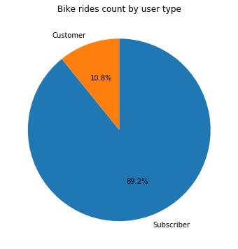

```python
# Pie chart depicting the percentage of customers and subscribers in the dataset
user = df.user_type.value_counts()

plt.figure(figsize=[8, 6])
plt.pie(user, labels = user.index, startangle = 90, counterclock=False, autopct ='%1.1f%%')
plt.title('Bike rides count by user type');
```

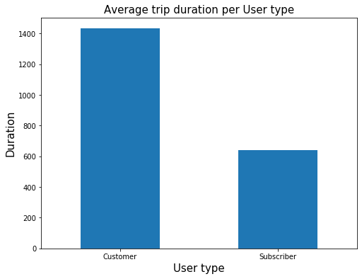

```python
# Plot of average trip duration per user type
plt.figure(figsize=[8, 6])
df.groupby('user_type').duration_sec.mean().plot(kind='bar')
plt.xticks(rotation = 'horizontal')
plt.xlabel('User type', size =15)
plt.ylabel('Duration', size =15)
plt.title('Average trip duration per User type', size =15);
```

From the pie chart, 89.2% of users of Ford GoBike are subscribers while 10.8% are customers. However, the average trip duration of Customers is longer than that of Subscribers.

### Discuss the distribution(s) of your variable(s) of interest. Were there any unusual points? Did you need to perform any transformations?

The peak times of using this bike sharing service during the day is around 8am (8:00) and 5pm (17:00). More bikes are also used during the week (Monday to Friday) than weekend (Saturday and Sunday) but on average, longer trips are taken during weekends than weekdays. I also observed that riders between 26 to 35 years mostly make use of this service and 89.2% of users are Subscribers.

These observations were made after investigating these features individually. In the next section, theese features would be explored jointly to find any correlation between them.

### Of the features you investigated, were there any unusual distributions? Did you perform any operations on the data to tidy, adjust, or change the form of the data? If so, why did you do this?

As regards to distribution of birth year, the maximum year is 2001 (18 years as at 2019). This shows the possibility of an age limit of 18 years for riders. The distribution also showed a minimum year of 1878 (141 years). This entry is an outlier but no operation was performed on it because it was a single entry and would have no effect on the overall analysis. Birth year column was used to craete the additional columns listed below.

```
- age - was gotten by subtracting birth year from 2019
- age_range - age was grouped as '<20', '21-25', '26-30', '31-35', '36-40', '41-45', '46-50', '51-55', '56-60' and '61+
```

Date and time was merged in the original dataset and had to be separated to different columns. Additionally, to better understand the when most trips are taken during the week, some columns was created from the start_time column. Their description are:

```
- start_dates - date trip was commenced
- start_times - time trip commenced
- day_of_week - contains 0-6 which represents Monday-Sunday
- time_of_day - hour trip started using 24-hour time
- time - Night, Morning, Afternoon or Evening
```

## Bivariate Exploration

In this section, I would jointly explore the features introduced in Univariate exploration section. Using charts, trips taken by riders in age groups would be explored.

#### Age group vs Time of day feature

```python
#define function to plot counplots
def myCountPlot(df, y, hue, palette=None, order=None, hue_order=None):
    plt.figure(figsize=[14,8])
    sb.countplot(data=df, y=y, hue=hue, edgecolor='black', palette=palette, order=order, hue_order=hue_order)
    y=y.replace('_',' ')
    hue=hue.replace('_',' ')
    plt.title(f'''Distribution of {y} by {hue}'''.title(), fontsize=10, weight='bold')
    plt.ylabel(y.title(), fontsize=10, weight='bold')
    plt.xlabel('Frequency'.title(), fontsize=10, weight='bold')
    sb.despine();
```

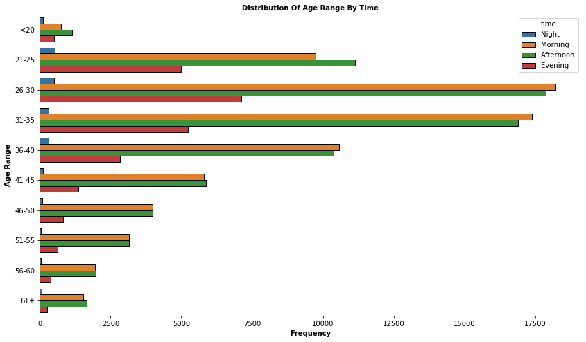

```python
#Trips taken at different times of the day by riders
myCountPlot(df, 'age_range', 'time')
```

As seen earlier, most trips are made in the morning and afternoon and from the above chart, we can see that it's the same across all age groups. Next, I would explore the characteristics of riders during the week by theri age groups.

#### Age group vs Day of week features

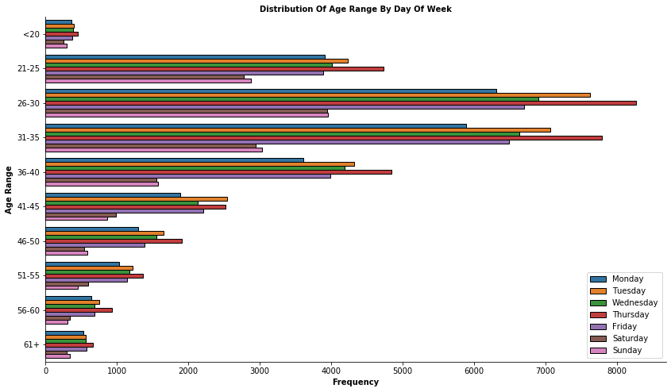

```python
#Trips taken at different days of week by riders
myCountPlot(df, y='age_range', hue='day_of_week')
plt.legend(order);
```

After exploring how riders use the service on a daily basis, I would explore user types of the different age groups to understand how they use the service daily.

#### Age group vs User type features

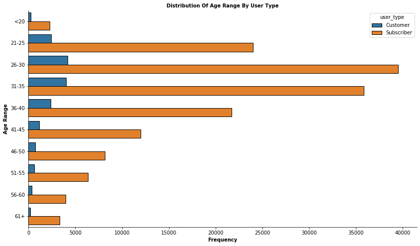

```python
# Trips taken by different users grouped by age
myCountPlot(df, 'age_range', 'user_type')
```

#### Day of week vs User type features

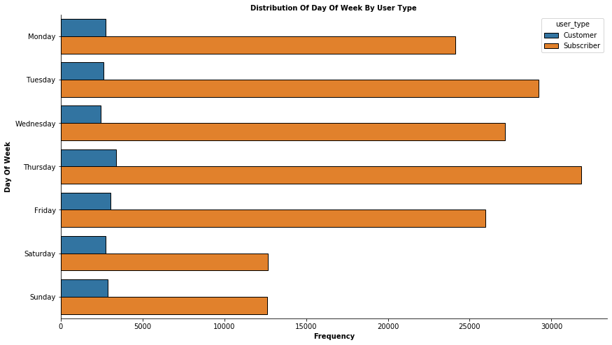

```python
#Trips taken by users on different days of week
myCountPlot(df, 'day_of_week', 'user_type')
plt.yticks(range(len(order)), order);
```

#### Age group vs Hour features

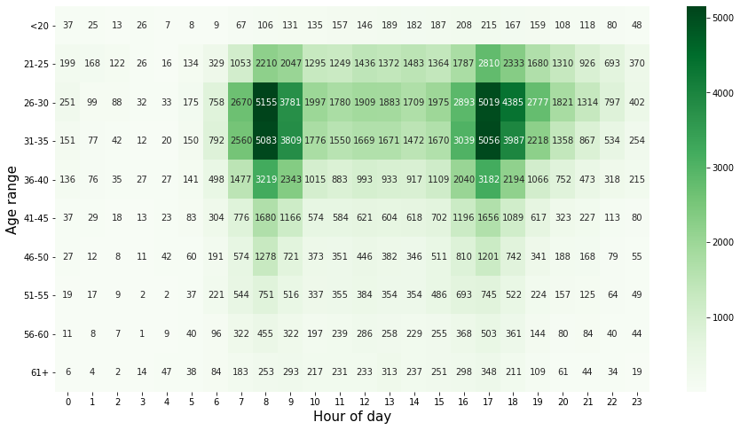

```python
# Group data by age group and hour
df_hour = df.groupby(['age_range', 'time_of_day']).size().reset_index(name='count')
df_hour = df_hour.pivot(index = 'age_range', columns = 'time_of_day', values = 'count')

# Plot heatmap of age group vs hour
plt.figure(figsize=[15, 8])
sb.heatmap(df_hour, annot = True, fmt = 'd', cmap='Greens')
plt.yticks(rotation = 360)
plt.xlabel('Hour of day', size=15)
plt.ylabel('Age range', size=15);
```

This heatmap clearly confirms our initial observation of the peak usage periods as 8am and 5pm by riders between 26-35 years old.

#### Age group vs Time features

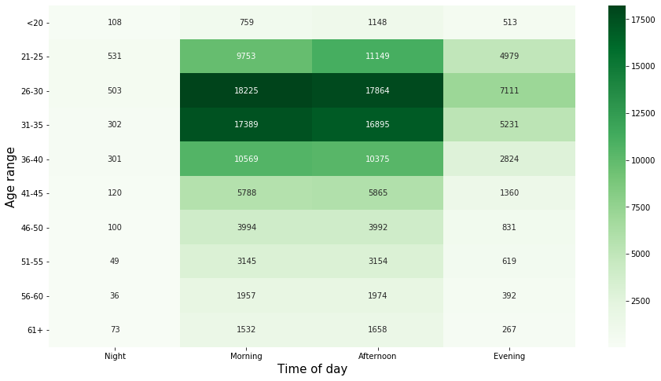

```python
# Group data by age group and time
df_time = df.groupby(['age_range', 'time']).size().reset_index(name='count')
df_time = df_time.pivot(index = 'age_range', columns = 'time', values = 'count')

# Plot heatmap of age group vs time
plt.figure(figsize=[15, 8])
sb.heatmap(df_time, annot = True, fmt = 'd', cmap='Greens')
plt.yticks(rotation = 360)
plt.xlabel('Time of day', size=15)
plt.ylabel('Age range', size=15);
```

#### Age group vs Day of week features

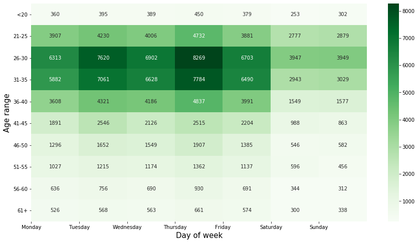

```python
# Group data by age group and day of week
df_day = df.groupby(['age_range', 'day_of_week']).size().reset_index(name='count')
df_day = df_day.pivot(index = 'age_range', columns = 'day_of_week', values = 'count')

# Plot heatmap of age group vs day of week
plt.figure(figsize=[15, 8])
sb.heatmap(df_day, annot = True, fmt = 'd', cmap='Greens')
plt.yticks(rotation = 360)
plt.xticks(range(len(order)), order)
plt.xlabel('Day of week', size=15)
plt.ylabel('Age range', size=15);
```

This heatmap also confirms the initial observation that most users aare betweeen 26-35 years old, though a good number(75%) of riders are between 21-40 years old.

### Did you observe any interesting relationships between the other features (not the main feature(s) of interest)?

Thursday has the record of the highest usage of bike for both Subscribers and Customers in the week. This could be caused bu various factors but the dataset does not contain enough information to determine the reason.

## Multivariate Exploration

In this section, I would jointly explore all features of interest which are user type, age group and day of week. The aim is to understand how Customers and Subcribers use the service daily according to their age groups.

#### User type by Age group vs Day of week features

```python
# Segment data by user type and group by day of week and age range
df_subscriber =df.query('user_type == "Subscriber"').groupby(['day_of_week', 'age_range']).size().reset_index(name='count')
df_subscriber = df_subscriber.pivot(index = 'day_of_week', columns = 'age_range', values = 'count')

df_customer = df.query('user_type == "Customer"').groupby(['day_of_week', 'age_range']).size().reset_index(name='count')
df_customer = df_customer.pivot(index = 'day_of_week', columns = 'age_range', values = 'count')
```

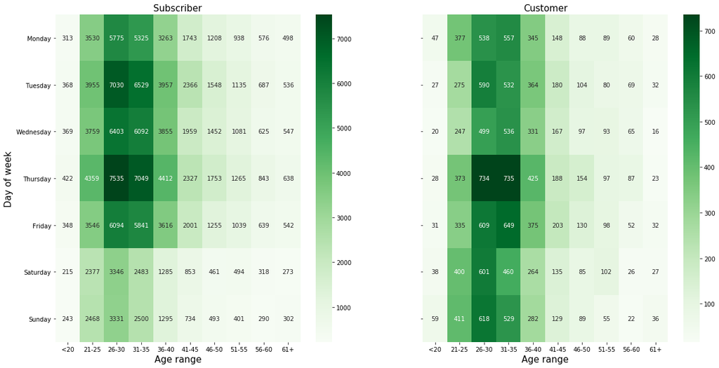

```python
#Plot heatmap for Subscribers and Customers
plt.subplots(figsize=(20,10))

# Heatmap for Subscribers
fig1 = plt.subplot(1,2,1)
ax1 = sb.heatmap(df_subscriber, annot=True, fmt='d', cmap='Greens')
ax1.set_ylabel('Day of week', size=15)
ax1.set_yticklabels(order)
ax1.set_xlabel('Age range', size=15)
ax1.set_title('Subscriber',size=15)
plt.yticks(rotation=360)

# Heatmap for Customers
fig2 = plt.subplot(1,2,2)
ax2 = sb.heatmap(df_customer, annot=True, fmt='d', cmap='Greens')
ax2.set_ylabel('')
ax2.set_yticklabels([])
ax2.set_xlabel('Age range', size=15)
ax2.set_title('Customer',size=15)
plt.yticks(rotation=360);
```

### Talk about some of the relationships you observed in this part of the investigation. Were there features that strengthened each other in terms of looking at your feature(s) of interest?

I observed that, although the age range of Subscribers and Customers who mostly use Ford GoBike service are the same, their usage patterns during the week varies. While Subscribers made trips mostly on weekdays, Customers regularly made trips every day of the week.

### Were there any interesting or surprising interactions between features?

Interestingly, I observed that Customers and Subscribers use the service mostly on Thursday. Additionally, Customers are distributed mainly between 21 to 40 years and there isn't much difference in their usage of Ford GoBike bike sharing service by this group of users during weekends and weekdays.

## Conclusions

Ford GoBike service is used mostly by Subscribers between 26 and 35 years during the week with peak usage times of 8am and 5pm. With the young age of this group, it shows that the service is used mainly by workers and individuals going to their work or business places in the morning and back home later in the day.

Subscribers make up 89.2% of users in the data while Customers make up 10.8%, indicating that Subscribers use the service more than Customers. Notwithstanding, the average duration of trips embarked on by Customers is twice more than that of Subscribers.

```python
# Save dataset for slide presentation
df.to_csv('201902-fordgobike-tripdata-updated.csv', index=False)
```